# Trp53cor1 KO vs WT (rmdup_kidney)

This file shows the wt-v-ko comparison for Trp53cor1.

Cuff overview:

```
## CuffSet instance with:
##   2 samples
##   26754 genes
##   77524 isoforms
##   0 TSS
##   23066 CDS
##   0 promoters
##   0 splicing
##   19954 relCDS
```

# QC

## Dispersion

Dispersion plot for genes in cuff: (Overdispersion can lead to innacurate quants)

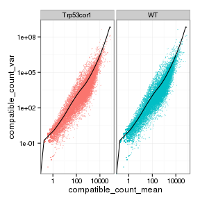

## Cross-replicate variability (fpkmSCVplot)

Differences in CV 2 can result in lower numbers of differentially expressed genes due to a higher degree of variability between replicate fpkm estimates.

Genes:

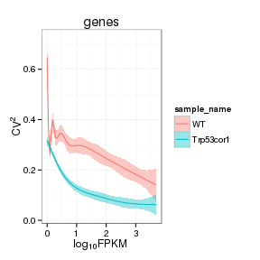

Isoforms:

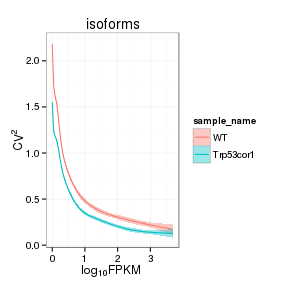

## MvA plot

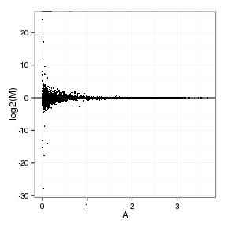

### MvA plot counts

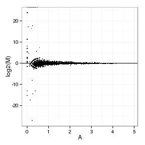

## Scatterplot matrix

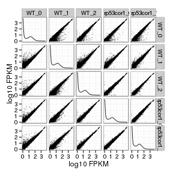

## Distributions

### Boxplots

Boxplot (genes)

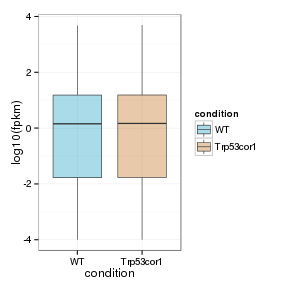

Boxplot (genes, replicates)

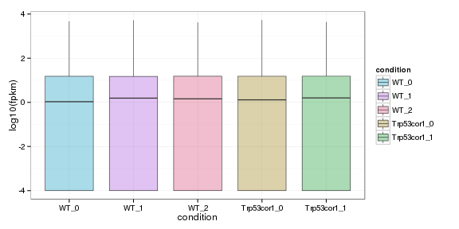

Boxplot (isoforms)

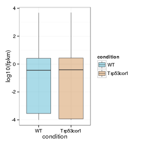

Boxplot (isoforms, replicates)

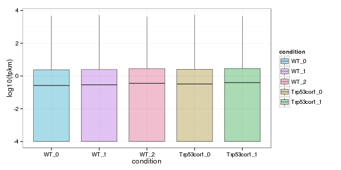

### Density

Density (genes)

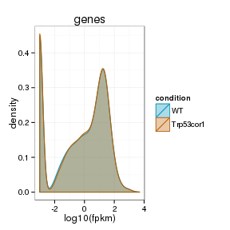

Density (genes, replicates)

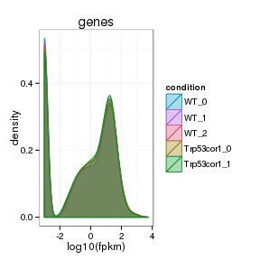

## Clustering

### Replicate Clusters

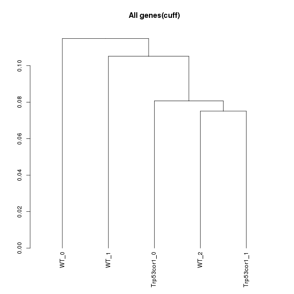

### PCA (genes)

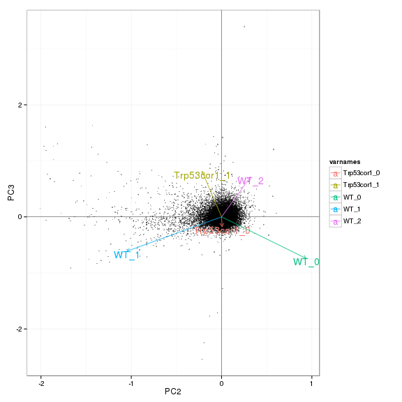

### MDS (genes)

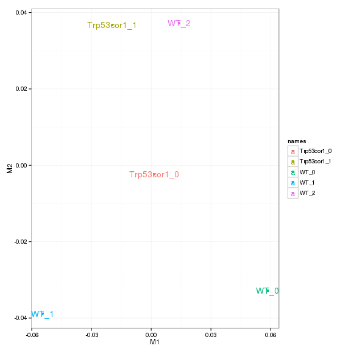

# KO assessment

## Endogenous lncRNA expression

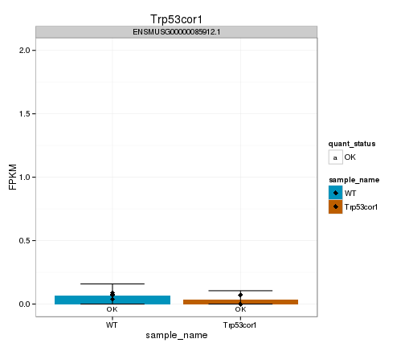

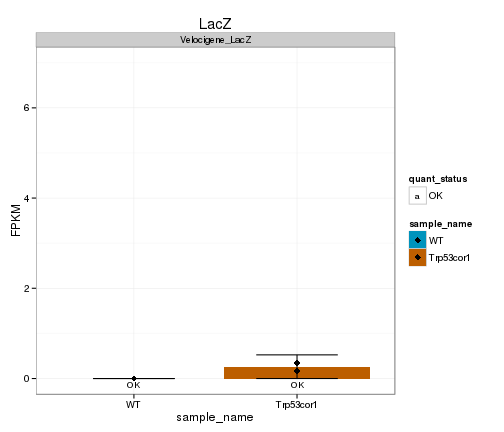

## Digital Genotyping (LacZ vs Endogenous lncRNA and Sex)

Eif2s3y is a y-expressed gene, Xist is an x-expressed gene Expression plot (endogenous linc, lacZ, Y-expressed gene):

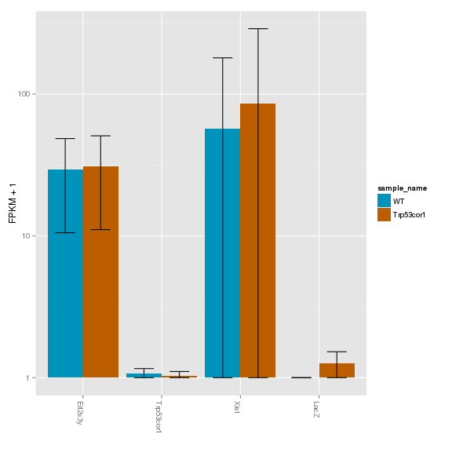

Expression heatmap:

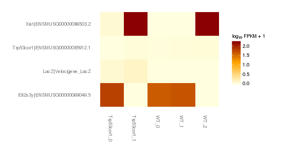

### Track visualization

[output not shown]

# Differential Analysis

## Differential Genes

There are 22 significantly differentially expressed genes. They are:

|  | geneAnnot$gene_short_name |
| --- | --- |
| 1 | Apoa2 |
| 2 | Slc4a1 |
| 3 | Myh3 |
| 4 | Ahsg |
| 5 | Rbp4 |
| 6 | Fga |
| 7 | Hemgn |
| 8 | Ambp |
| 9 | Alb |
| 10 | Apoa1 |
| 11 | Rnps1 |
| 12 | Itih2 |
| 13 | Col6a6 |
| 14 | Gm4737 |
| 15 | Gypa |
| 16 | Actn2 |
| 17 | Afp |
| 18 | Myh8 |
| 19 | Serpina6 |
| 20 | Serpina1b |
| 21 | Hmga1-rs1 |
| 22 | Gm9825 |

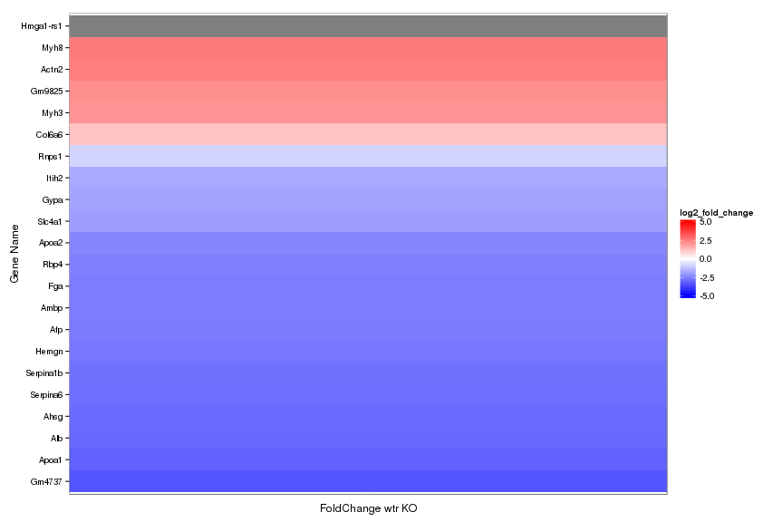

Expression heatmap of sigGenes

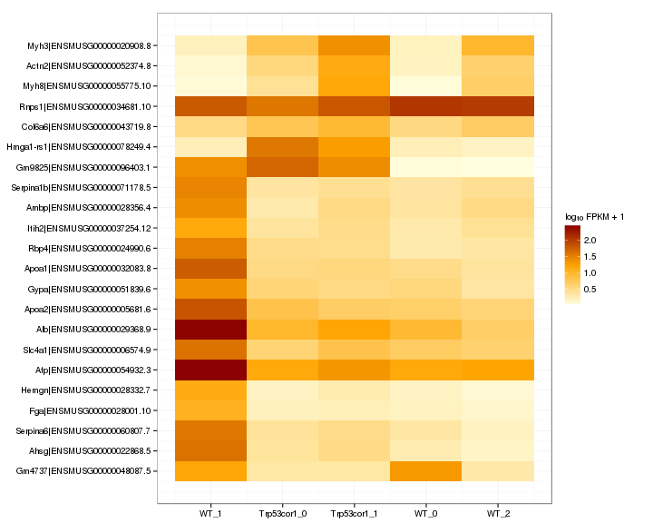

Foldchange heatmap of sigGenes

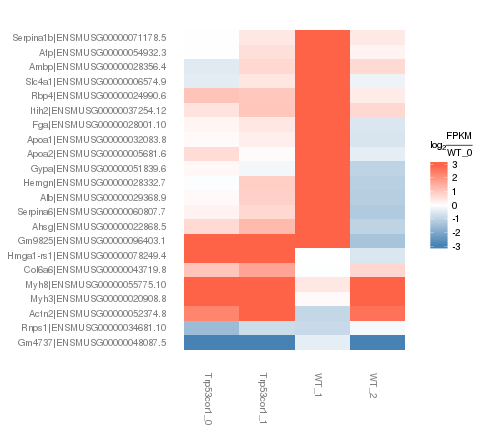

Now, look at genes that are detectably expressed (FPKM>0.5, yes I know it should be 1), and log2foldchange>2 in any direction: 121 genes

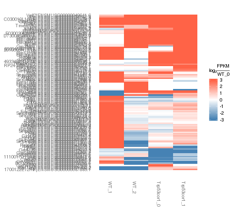

Now, those that are expressed, changing and called sig: 17 genes

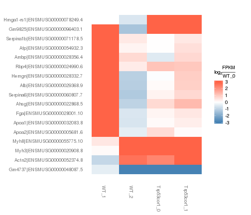

### Expression-level/significance relationship

Scatter plot of significant genes only:

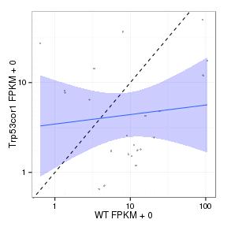

Volcano Plot

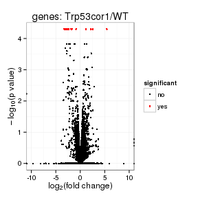

Volcano plot with significant genes only:

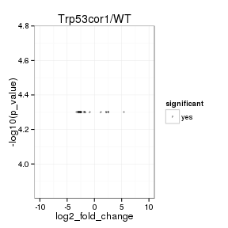

### Differential Isoforms between conditions

Per isoform difference between conditions:

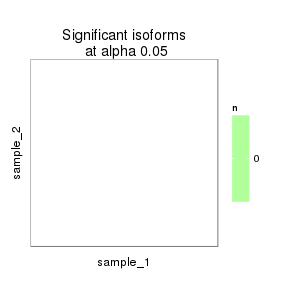

These isoforms are:

[1] “no sig isoforms”

DE isoform heatmap

```
## [1] "no sig isoforms"
```

Isoform foldchange heatmap by isoform:

```
## [1] "no sig isoforms"
```

# Gene/Pathway Analysis

## GSEA

Enrichment and zscores are calculated based on expression in KO vs WT (fpkmKO/fpkmWT), so genes that are down regulated in KO are shown in blue, while upregulation is shown in red.

KO/WT Blue = down in KO Red = Up in KO

Biocarta enrichment:

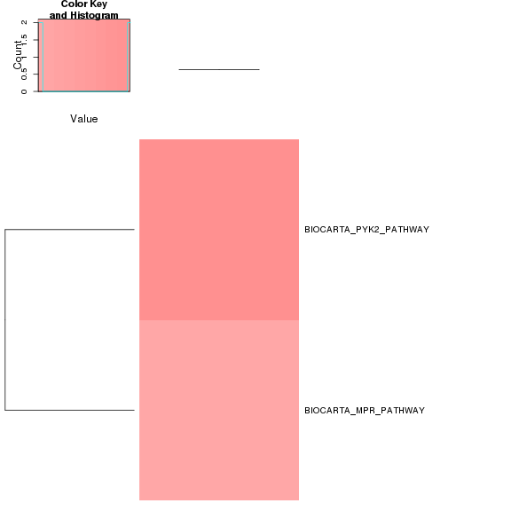

Biocarta zscore:

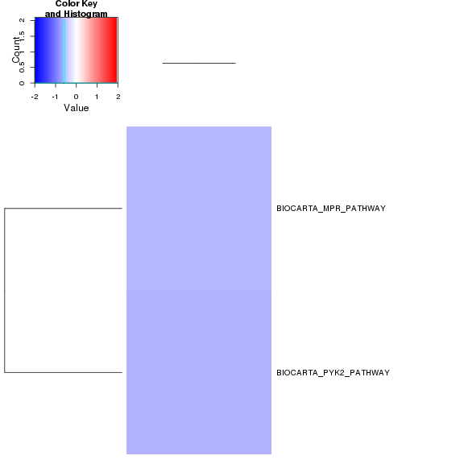

Reactome enrichment:

[output not shown]

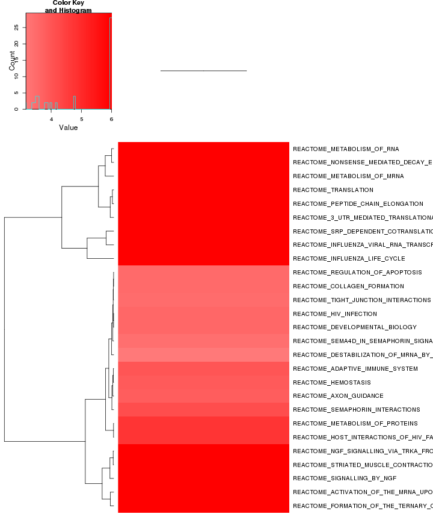

Reactome zscore:

[output not shown]